# Risk Factor Analysis

## Outcome Variable

**Outcome Variable:** sstunted

## Predictor Variables

**Intervention Variable:** fage

**Adjustment Set:**

unadjusted

## Stratifying Variables

The analysis was stratified on these variable(s):

- agecat
- studyid
- country

## Data Summary

| agecat | studyid | country | fage | sstunted | n_cell | n |
| --- | --- | --- | --- | --- | --- | --- |
| Birth | ki0047075b-MAL-ED | BANGLADESH | >=38 | 0 | 66 | 145 |
| Birth | ki0047075b-MAL-ED | BANGLADESH | >=38 | 1 | 1 | 145 |
| Birth | ki0047075b-MAL-ED | BANGLADESH | <32 | 0 | 26 | 145 |
| Birth | ki0047075b-MAL-ED | BANGLADESH | <32 | 1 | 1 | 145 |
| Birth | ki0047075b-MAL-ED | BANGLADESH | [32-38) | 0 | 50 | 145 |
| Birth | ki0047075b-MAL-ED | BANGLADESH | [32-38) | 1 | 1 | 145 |
| Birth | ki0047075b-MAL-ED | BRAZIL | >=38 | 0 | 25 | 68 |
| Birth | ki0047075b-MAL-ED | BRAZIL | >=38 | 1 | 2 | 68 |
| Birth | ki0047075b-MAL-ED | BRAZIL | <32 | 0 | 16 | 68 |
| Birth | ki0047075b-MAL-ED | BRAZIL | <32 | 1 | 0 | 68 |
| Birth | ki0047075b-MAL-ED | BRAZIL | [32-38) | 0 | 24 | 68 |
| Birth | ki0047075b-MAL-ED | BRAZIL | [32-38) | 1 | 1 | 68 |
| Birth | ki0047075b-MAL-ED | INDIA | >=38 | 0 | 26 | 131 |
| Birth | ki0047075b-MAL-ED | INDIA | >=38 | 1 | 1 | 131 |
| Birth | ki0047075b-MAL-ED | INDIA | <32 | 0 | 43 | 131 |
| Birth | ki0047075b-MAL-ED | INDIA | <32 | 1 | 1 | 131 |
| Birth | ki0047075b-MAL-ED | INDIA | [32-38) | 0 | 58 | 131 |
| Birth | ki0047075b-MAL-ED | INDIA | [32-38) | 1 | 2 | 131 |
| Birth | ki0047075b-MAL-ED | NEPAL | >=38 | 0 | 13 | 61 |
| Birth | ki0047075b-MAL-ED | NEPAL | >=38 | 1 | 0 | 61 |
| Birth | ki0047075b-MAL-ED | NEPAL | <32 | 0 | 9 | 61 |
| Birth | ki0047075b-MAL-ED | NEPAL | <32 | 1 | 0 | 61 |
| Birth | ki0047075b-MAL-ED | NEPAL | [32-38) | 0 | 37 | 61 |
| Birth | ki0047075b-MAL-ED | NEPAL | [32-38) | 1 | 2 | 61 |
| Birth | ki0047075b-MAL-ED | PERU | >=38 | 0 | 27 | 80 |
| Birth | ki0047075b-MAL-ED | PERU | >=38 | 1 | 0 | 80 |
| Birth | ki0047075b-MAL-ED | PERU | <32 | 0 | 27 | 80 |
| Birth | ki0047075b-MAL-ED | PERU | <32 | 1 | 0 | 80 |
| Birth | ki0047075b-MAL-ED | PERU | [32-38) | 0 | 26 | 80 |
| Birth | ki0047075b-MAL-ED | PERU | [32-38) | 1 | 0 | 80 |

[output cut: 180 more lines]

The following strata were considered:

- agecat: 24 months, studyid: ki0047075b-MAL-ED, country: BANGLADESH
- agecat: 24 months, studyid: ki0047075b-MAL-ED, country: BRAZIL
- agecat: 24 months, studyid: ki0047075b-MAL-ED, country: INDIA
- agecat: 24 months, studyid: ki0047075b-MAL-ED, country: NEPAL
- agecat: 24 months, studyid: ki0047075b-MAL-ED, country: PERU
- agecat: 24 months, studyid: ki0047075b-MAL-ED, country: SOUTH AFRICA
- agecat: 24 months, studyid: ki0047075b-MAL-ED, country: TANZANIA, UNITED REPUBLIC OF
- agecat: 24 months, studyid: ki1119695-PROBIT, country: BELARUS
- agecat: 24 months, studyid: ki1135781-COHORTS, country: GUATEMALA
- agecat: 24 months, studyid: ki1135781-COHORTS, country: PHILIPPINES
- agecat: 24 months, studyid: ki1148112-LCNI-5, country: MALAWI
- agecat: 6 months, studyid: ki0047075b-MAL-ED, country: BANGLADESH
- agecat: 6 months, studyid: ki0047075b-MAL-ED, country: BRAZIL
- agecat: 6 months, studyid: ki0047075b-MAL-ED, country: INDIA
- agecat: 6 months, studyid: ki0047075b-MAL-ED, country: NEPAL
- agecat: 6 months, studyid: ki0047075b-MAL-ED, country: PERU
- agecat: 6 months, studyid: ki0047075b-MAL-ED, country: SOUTH AFRICA
- agecat: 6 months, studyid: ki0047075b-MAL-ED, country: TANZANIA, UNITED REPUBLIC OF
- agecat: 6 months, studyid: ki1000304b-SAS-CompFeed, country: INDIA
- agecat: 6 months, studyid: ki1000304b-SAS-FoodSuppl, country: INDIA
- agecat: 6 months, studyid: ki1119695-PROBIT, country: BELARUS
- agecat: 6 months, studyid: ki1135781-COHORTS, country: GUATEMALA
- agecat: 6 months, studyid: ki1135781-COHORTS, country: PHILIPPINES
- agecat: 6 months, studyid: ki1148112-LCNI-5, country: MALAWI
- agecat: Birth, studyid: ki0047075b-MAL-ED, country: BANGLADESH
- agecat: Birth, studyid: ki0047075b-MAL-ED, country: BRAZIL
- agecat: Birth, studyid: ki0047075b-MAL-ED, country: INDIA
- agecat: Birth, studyid: ki0047075b-MAL-ED, country: NEPAL
- agecat: Birth, studyid: ki0047075b-MAL-ED, country: PERU
- agecat: Birth, studyid: ki0047075b-MAL-ED, country: SOUTH AFRICA
- agecat: Birth, studyid: ki0047075b-MAL-ED, country: TANZANIA, UNITED REPUBLIC OF
- agecat: Birth, studyid: ki1000304b-SAS-CompFeed, country: INDIA
- agecat: Birth, studyid: ki1119695-PROBIT, country: BELARUS
- agecat: Birth, studyid: ki1135781-COHORTS, country: GUATEMALA
- agecat: Birth, studyid: ki1135781-COHORTS, country: PHILIPPINES

### Dropped Strata

Some strata were dropped due to rare outcomes:

- agecat: Birth, studyid: ki0047075b-MAL-ED, country: BANGLADESH
- agecat: Birth, studyid: ki0047075b-MAL-ED, country: BRAZIL
- agecat: Birth, studyid: ki0047075b-MAL-ED, country: INDIA
- agecat: Birth, studyid: ki0047075b-MAL-ED, country: NEPAL
- agecat: Birth, studyid: ki0047075b-MAL-ED, country: PERU
- agecat: Birth, studyid: ki0047075b-MAL-ED, country: SOUTH AFRICA
- agecat: Birth, studyid: ki0047075b-MAL-ED, country: TANZANIA, UNITED REPUBLIC OF
- agecat: Birth, studyid: ki1000304b-SAS-CompFeed, country: INDIA
- agecat: Birth, studyid: ki1119695-PROBIT, country: BELARUS
- agecat: Birth, studyid: ki1135781-COHORTS, country: GUATEMALA
- agecat: 6 months, studyid: ki0047075b-MAL-ED, country: BANGLADESH
- agecat: 6 months, studyid: ki0047075b-MAL-ED, country: BRAZIL
- agecat: 6 months, studyid: ki0047075b-MAL-ED, country: INDIA
- agecat: 6 months, studyid: ki0047075b-MAL-ED, country: NEPAL
- agecat: 6 months, studyid: ki0047075b-MAL-ED, country: PERU
- agecat: 6 months, studyid: ki0047075b-MAL-ED, country: SOUTH AFRICA
- agecat: 6 months, studyid: ki0047075b-MAL-ED, country: TANZANIA, UNITED REPUBLIC OF
- agecat: 6 months, studyid: ki1148112-LCNI-5, country: MALAWI
- agecat: 24 months, studyid: ki0047075b-MAL-ED, country: BRAZIL
- agecat: 24 months, studyid: ki0047075b-MAL-ED, country: INDIA
- agecat: 24 months, studyid: ki0047075b-MAL-ED, country: NEPAL
- agecat: 24 months, studyid: ki0047075b-MAL-ED, country: PERU
- agecat: 24 months, studyid: ki0047075b-MAL-ED, country: SOUTH AFRICA
- agecat: 24 months, studyid: ki1119695-PROBIT, country: BELARUS
- agecat: 24 months, studyid: ki1148112-LCNI-5, country: MALAWI

## Methods Detail

We’re interested in the causal parameters $E[Y_a]$ for all values of $a \in \mathcal{A}$. These parameters represent the mean outcome if, possibly contrary to fact, we intervened to set all units to have $A=a$. Under the randomization and positivity assumptions, these are identified by the statistical parameters $\psi_a=E_W[E_{Y|A,W}(Y|A=a,W)]$. In addition, we’re interested in the mean of $Y$, $E[Y]$ under no intervention (the observed mean). We will estimate these parameters by using SuperLearner to fit the relevant likelihood factors – $E_{Y|A,W}(Y|A=a,W)$ and $p(A=a|W)$, and then updating our likelihood fit using a joint TMLE.

For unadjusted analyses ($W=\{\}$), initial likelihoods were estimated using Lrnr_glm to estimate the simple $E(Y|A)$ and Lrnr_mean to estimate $p(A)$. For adjusted analyses, a small library containing Lrnr_glmnet, Lrnr_xgboost, and Lrnr_mean was used.

Having estimated these parameters, we will then use the delta method to estimate relative risks and attributable risks relative to a prespecified baseline level of $A$.

# Results Detail

## Results Plots

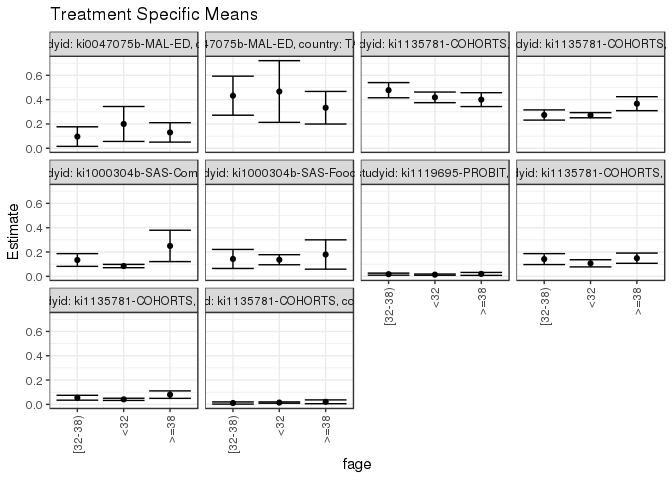

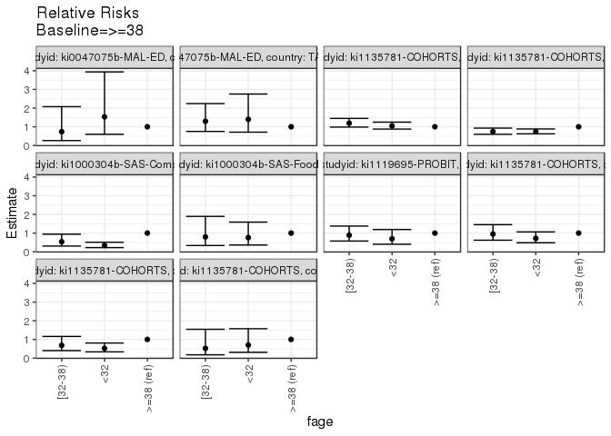

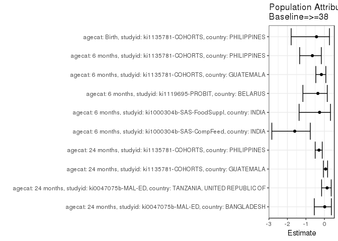

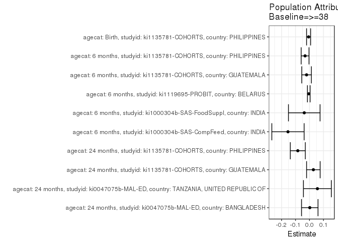

## Results Table

### Parameter: TSM

| agecat | studyid | country | intervention_level | baseline_level | estimate | ci_lower | ci_upper |
| --- | --- | --- | --- | --- | --- | --- | --- |
| Birth | ki1135781-COHORTS | PHILIPPINES | >=38 | NA | 0.0213415 | 0.0056987 | 0.0369842 |
| Birth | ki1135781-COHORTS | PHILIPPINES | <32 | NA | 0.0149110 | 0.0097004 | 0.0201216 |
| Birth | ki1135781-COHORTS | PHILIPPINES | [32-38) | NA | 0.0111732 | 0.0022815 | 0.0200649 |
| 6 months | ki1000304b-SAS-CompFeed | INDIA | >=38 | NA | 0.2500000 | 0.1210063 | 0.3789937 |
| 6 months | ki1000304b-SAS-CompFeed | INDIA | <32 | NA | 0.0844444 | 0.0709188 | 0.0979701 |
| 6 months | ki1000304b-SAS-CompFeed | INDIA | [32-38) | NA | 0.1341463 | 0.0817771 | 0.1865156 |
| 6 months | ki1000304b-SAS-FoodSuppl | INDIA | >=38 | NA | 0.1794872 | 0.0588872 | 0.3000872 |
| 6 months | ki1000304b-SAS-FoodSuppl | INDIA | <32 | NA | 0.1363636 | 0.0949128 | 0.1778145 |
| 6 months | ki1000304b-SAS-FoodSuppl | INDIA | [32-38) | NA | 0.1428571 | 0.0645949 | 0.2211194 |
| 6 months | ki1119695-PROBIT | BELARUS | >=38 | NA | 0.0199715 | 0.0079011 | 0.0320419 |
| 6 months | ki1119695-PROBIT | BELARUS | <32 | NA | 0.0138798 | 0.0088568 | 0.0189027 |
| 6 months | ki1119695-PROBIT | BELARUS | [32-38) | NA | 0.0177797 | 0.0093708 | 0.0261887 |
| 6 months | ki1135781-COHORTS | GUATEMALA | >=38 | NA | 0.1490909 | 0.1069715 | 0.1912104 |
| 6 months | ki1135781-COHORTS | GUATEMALA | <32 | NA | 0.1068884 | 0.0773587 | 0.1364181 |
| 6 months | ki1135781-COHORTS | GUATEMALA | [32-38) | NA | 0.1416309 | 0.0968369 | 0.1864249 |
| 6 months | ki1135781-COHORTS | PHILIPPINES | >=38 | NA | 0.0800000 | 0.0492950 | 0.1107050 |
| 6 months | ki1135781-COHORTS | PHILIPPINES | <32 | NA | 0.0415528 | 0.0324051 | 0.0507004 |
| 6 months | ki1135781-COHORTS | PHILIPPINES | [32-38) | NA | 0.0545455 | 0.0345363 | 0.0745546 |
| 24 months | ki0047075b-MAL-ED | BANGLADESH | >=38 | NA | 0.1304348 | 0.0507062 | 0.2101634 |
| 24 months | ki0047075b-MAL-ED | BANGLADESH | <32 | NA | 0.2000000 | 0.0563881 | 0.3436119 |
| 24 months | ki0047075b-MAL-ED | BANGLADESH | [32-38) | NA | 0.0961538 | 0.0157606 | 0.1765471 |
| 24 months | ki0047075b-MAL-ED | TANZANIA, UNITED REPUBLIC OF | >=38 | NA | 0.3333333 | 0.1993028 | 0.4673638 |
| 24 months | ki0047075b-MAL-ED | TANZANIA, UNITED REPUBLIC OF | <32 | NA | 0.4666667 | 0.2129274 | 0.7204059 |
| 24 months | ki0047075b-MAL-ED | TANZANIA, UNITED REPUBLIC OF | [32-38) | NA | 0.4324324 | 0.2719980 | 0.5928669 |
| 24 months | ki1135781-COHORTS | GUATEMALA | >=38 | NA | 0.4000000 | 0.3430959 | 0.4569041 |
| 24 months | ki1135781-COHORTS | GUATEMALA | <32 | NA | 0.4186992 | 0.3750849 | 0.4623135 |
| 24 months | ki1135781-COHORTS | GUATEMALA | [32-38) | NA | 0.4777328 | 0.4154095 | 0.5400561 |
| 24 months | ki1135781-COHORTS | PHILIPPINES | >=38 | NA | 0.3666667 | 0.3091744 | 0.4241590 |
| 24 months | ki1135781-COHORTS | PHILIPPINES | <32 | NA | 0.2719088 | 0.2505387 | 0.2932789 |
| 24 months | ki1135781-COHORTS | PHILIPPINES | [32-38) | NA | 0.2735632 | 0.2316624 | 0.3154641 |

### Parameter: E(Y)

| agecat | studyid | country | intervention_level | baseline_level | estimate | ci_lower | ci_upper |
| --- | --- | --- | --- | --- | --- | --- | --- |
| Birth | ki1135781-COHORTS | PHILIPPINES | NA | NA | 0.0149457 | 0.0105620 | 0.0193293 |
| 6 months | ki1000304b-SAS-CompFeed | INDIA | NA | NA | 0.0960240 | 0.0777684 | 0.1142796 |
| 6 months | ki1000304b-SAS-FoodSuppl | INDIA | NA | NA | 0.1421053 | 0.1069532 | 0.1772573 |
| 6 months | ki1119695-PROBIT | BELARUS | NA | NA | 0.0147533 | 0.0094871 | 0.0200196 |
| 6 months | ki1135781-COHORTS | GUATEMALA | NA | NA | 0.1280947 | 0.1065929 | 0.1495965 |
| 6 months | ki1135781-COHORTS | PHILIPPINES | NA | NA | 0.0483994 | 0.0401865 | 0.0566123 |
| 24 months | ki0047075b-MAL-ED | BANGLADESH | NA | NA | 0.1324503 | 0.0782033 | 0.1866974 |
| 24 months | ki0047075b-MAL-ED | TANZANIA, UNITED REPUBLIC OF | NA | NA | 0.3900000 | 0.2939212 | 0.4860788 |
| 24 months | ki1135781-COHORTS | GUATEMALA | NA | NA | 0.4277344 | 0.3974167 | 0.4580521 |
| 24 months | ki1135781-COHORTS | PHILIPPINES | NA | NA | 0.2830030 | 0.2648675 | 0.3011384 |

### Parameter: RR

| agecat | studyid | country | intervention_level | baseline_level | estimate | ci_lower | ci_upper |
| --- | --- | --- | --- | --- | --- | --- | --- |
| Birth | ki1135781-COHORTS | PHILIPPINES | >=38 | >=38 | 1.0000000 | 1.0000000 | 1.0000000 |
| Birth | ki1135781-COHORTS | PHILIPPINES | <32 | >=38 | 0.6986876 | 0.3101923 | 1.5737474 |
| Birth | ki1135781-COHORTS | PHILIPPINES | [32-38) | >=38 | 0.5235435 | 0.1774516 | 1.5446338 |
| 6 months | ki1000304b-SAS-CompFeed | INDIA | >=38 | >=38 | 1.0000000 | 1.0000000 | 1.0000000 |
| 6 months | ki1000304b-SAS-CompFeed | INDIA | <32 | >=38 | 0.3377778 | 0.2232870 | 0.5109739 |
| 6 months | ki1000304b-SAS-CompFeed | INDIA | [32-38) | >=38 | 0.5365854 | 0.3051201 | 0.9436411 |
| 6 months | ki1000304b-SAS-FoodSuppl | INDIA | >=38 | >=38 | 1.0000000 | 1.0000000 | 1.0000000 |
| 6 months | ki1000304b-SAS-FoodSuppl | INDIA | <32 | >=38 | 0.7597403 | 0.3633993 | 1.5883498 |
| 6 months | ki1000304b-SAS-FoodSuppl | INDIA | [32-38) | >=38 | 0.7959184 | 0.3344716 | 1.8939907 |
| 6 months | ki1119695-PROBIT | BELARUS | >=38 | >=38 | 1.0000000 | 1.0000000 | 1.0000000 |
| 6 months | ki1119695-PROBIT | BELARUS | <32 | >=38 | 0.6949796 | 0.4049094 | 1.1928510 |
| 6 months | ki1119695-PROBIT | BELARUS | [32-38) | >=38 | 0.8902552 | 0.5758992 | 1.3762034 |
| 6 months | ki1135781-COHORTS | GUATEMALA | >=38 | >=38 | 1.0000000 | 1.0000000 | 1.0000000 |
| 6 months | ki1135781-COHORTS | GUATEMALA | <32 | >=38 | 0.7169341 | 0.4829174 | 1.0643530 |
| 6 months | ki1135781-COHORTS | GUATEMALA | [32-38) | >=38 | 0.9499634 | 0.6216321 | 1.4517115 |
| 6 months | ki1135781-COHORTS | PHILIPPINES | >=38 | >=38 | 1.0000000 | 1.0000000 | 1.0000000 |
| 6 months | ki1135781-COHORTS | PHILIPPINES | <32 | >=38 | 0.5194095 | 0.3336949 | 0.8084818 |
| 6 months | ki1135781-COHORTS | PHILIPPINES | [32-38) | >=38 | 0.6818182 | 0.4009514 | 1.1594324 |
| 24 months | ki0047075b-MAL-ED | BANGLADESH | >=38 | >=38 | 1.0000000 | 1.0000000 | 1.0000000 |
| 24 months | ki0047075b-MAL-ED | BANGLADESH | <32 | >=38 | 1.5333333 | 0.5971717 | 3.9370775 |
| 24 months | ki0047075b-MAL-ED | BANGLADESH | [32-38) | >=38 | 0.7371795 | 0.2616821 | 2.0766941 |
| 24 months | ki0047075b-MAL-ED | TANZANIA, UNITED REPUBLIC OF | >=38 | >=38 | 1.0000000 | 1.0000000 | 1.0000000 |
| 24 months | ki0047075b-MAL-ED | TANZANIA, UNITED REPUBLIC OF | <32 | >=38 | 1.4000000 | 0.7119272 | 2.7530904 |
| 24 months | ki0047075b-MAL-ED | TANZANIA, UNITED REPUBLIC OF | [32-38) | >=38 | 1.2972973 | 0.7506467 | 2.2420404 |
| 24 months | ki1135781-COHORTS | GUATEMALA | >=38 | >=38 | 1.0000000 | 1.0000000 | 1.0000000 |
| 24 months | ki1135781-COHORTS | GUATEMALA | <32 | >=38 | 1.0467480 | 0.8775412 | 1.2485810 |
| 24 months | ki1135781-COHORTS | GUATEMALA | [32-38) | >=38 | 1.1943320 | 0.9846851 | 1.4486142 |
| 24 months | ki1135781-COHORTS | PHILIPPINES | >=38 | >=38 | 1.0000000 | 1.0000000 | 1.0000000 |
| 24 months | ki1135781-COHORTS | PHILIPPINES | <32 | >=38 | 0.7415694 | 0.6222719 | 0.8837377 |
| 24 months | ki1135781-COHORTS | PHILIPPINES | [32-38) | >=38 | 0.7460815 | 0.5992279 | 0.9289247 |

### Parameter: PAR

| agecat | studyid | country | intervention_level | baseline_level | estimate | ci_lower | ci_upper |
| --- | --- | --- | --- | --- | --- | --- | --- |
| Birth | ki1135781-COHORTS | PHILIPPINES | >=38 | NA | -0.0063958 | -0.0208660 | 0.0080744 |
| 6 months | ki1000304b-SAS-CompFeed | INDIA | >=38 | NA | -0.1539760 | -0.2695126 | -0.0384394 |
| 6 months | ki1000304b-SAS-FoodSuppl | INDIA | >=38 | NA | -0.0373819 | -0.1504952 | 0.0757313 |
| 6 months | ki1119695-PROBIT | BELARUS | >=38 | NA | -0.0052181 | -0.0148642 | 0.0044279 |
| 6 months | ki1135781-COHORTS | GUATEMALA | >=38 | NA | -0.0209962 | -0.0554357 | 0.0134433 |
| 6 months | ki1135781-COHORTS | PHILIPPINES | >=38 | NA | -0.0316006 | -0.0597905 | -0.0034107 |
| 24 months | ki0047075b-MAL-ED | BANGLADESH | >=38 | NA | 0.0020155 | -0.0570607 | 0.0610918 |
| 24 months | ki0047075b-MAL-ED | TANZANIA, UNITED REPUBLIC OF | >=38 | NA | 0.0566667 | -0.0430816 | 0.1564149 |
| 24 months | ki1135781-COHORTS | GUATEMALA | >=38 | NA | 0.0277344 | -0.0207918 | 0.0762606 |
| 24 months | ki1135781-COHORTS | PHILIPPINES | >=38 | NA | -0.0836637 | -0.1373429 | -0.0299845 |

### Parameter: PAF

| agecat | studyid | country | intervention_level | baseline_level | estimate | ci_lower | ci_upper |
| --- | --- | --- | --- | --- | --- | --- | --- |
| Birth | ki1135781-COHORTS | PHILIPPINES | >=38 | NA | -0.4279379 | -1.7976835 | 0.2711804 |
| 6 months | ki1000304b-SAS-CompFeed | INDIA | >=38 | NA | -1.6035156 | -2.8419579 | -0.7642811 |
| 6 months | ki1000304b-SAS-FoodSuppl | INDIA | >=38 | NA | -0.2630579 | -1.3691050 | 0.3266169 |
| 6 months | ki1119695-PROBIT | BELARUS | >=38 | NA | -0.3536912 | -1.1635557 | 0.1530240 |
| 6 months | ki1135781-COHORTS | GUATEMALA | >=38 | NA | -0.1639114 | -0.4651907 | 0.0754175 |
| 6 months | ki1135781-COHORTS | PHILIPPINES | >=38 | NA | -0.6529134 | -1.3386395 | -0.1682530 |
| 24 months | ki0047075b-MAL-ED | BANGLADESH | >=38 | NA | 0.0152174 | -0.5489119 | 0.3738851 |
| 24 months | ki0047075b-MAL-ED | TANZANIA, UNITED REPUBLIC OF | >=38 | NA | 0.1452991 | -0.1531681 | 0.3665160 |
| 24 months | ki1135781-COHORTS | GUATEMALA | >=38 | NA | 0.0648402 | -0.0558196 | 0.1717109 |
| 24 months | ki1135781-COHORTS | PHILIPPINES | >=38 | NA | -0.2956284 | -0.4999177 | -0.1191634 |